# coconuts slides

## Singaporean Coconuts

In the nation's first years as the independent Republic of Singapore, coconut production was at an all time high. Soon, however, there was a steep decline in coconut production! I intend to find out why.

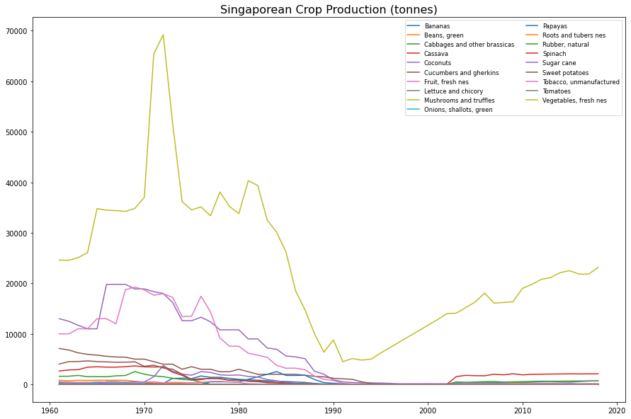

```python
big_plot(all_crops_production, "Singaporean Crop Production (tonnes)")
```

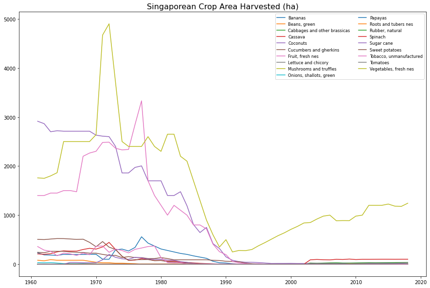

```python
big_plot(all_crops_area, "Singaporean Crop Area Harvested (ha)")
```

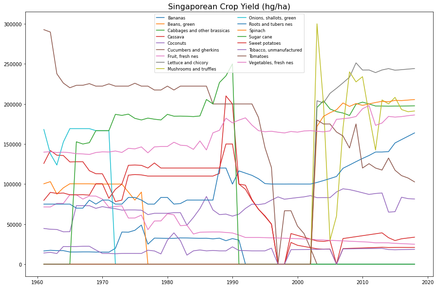

```python
big_plot(all_crops_yield, "Singaporean Crop Yield (hg/ha)")
```

It looks like production and area harvested have gone down significantly, while yield is a hot mess. It looks like production and area harvested starts going down around the late 70s and early 80s. This is somewhat consistent with [this book from the US government](http://countrystudies.us/singapore/39.htm), which says that agriculture started getting phased out in the late 1980s to be replaced with industry. Let's take a look at the yield of high performing crops and our personal favorite, the humble coconut.

```
Crop Yield
```

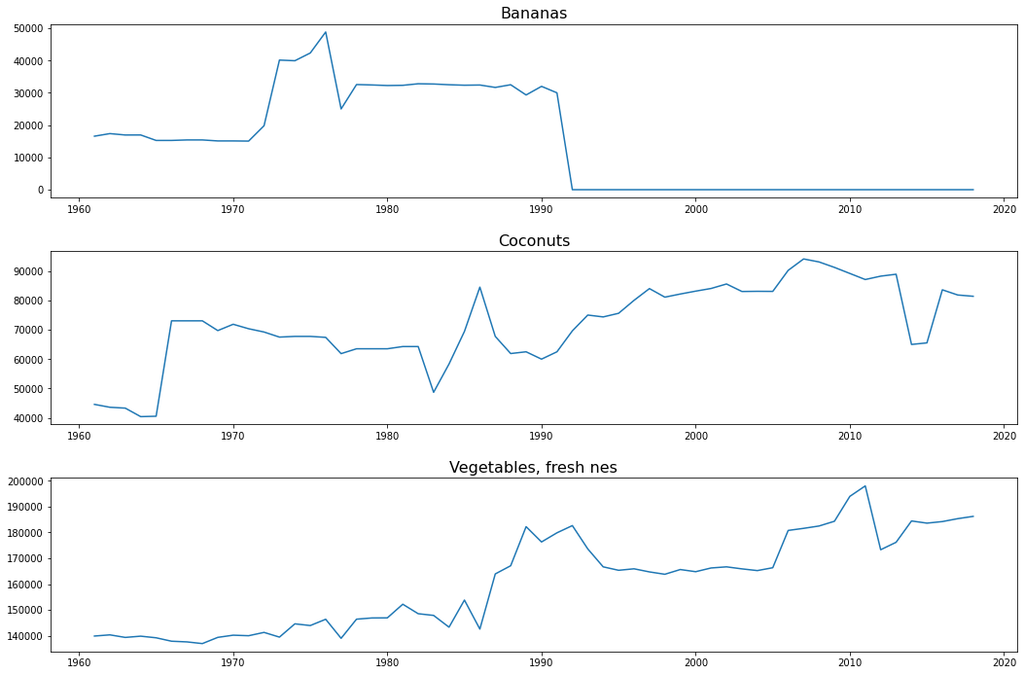

```python
print("Crop Yield")
small_plot(all_crops_yield, ["Bananas", "Coconuts", "Vegetables, fresh nes"])
```

```
Crop Production
```

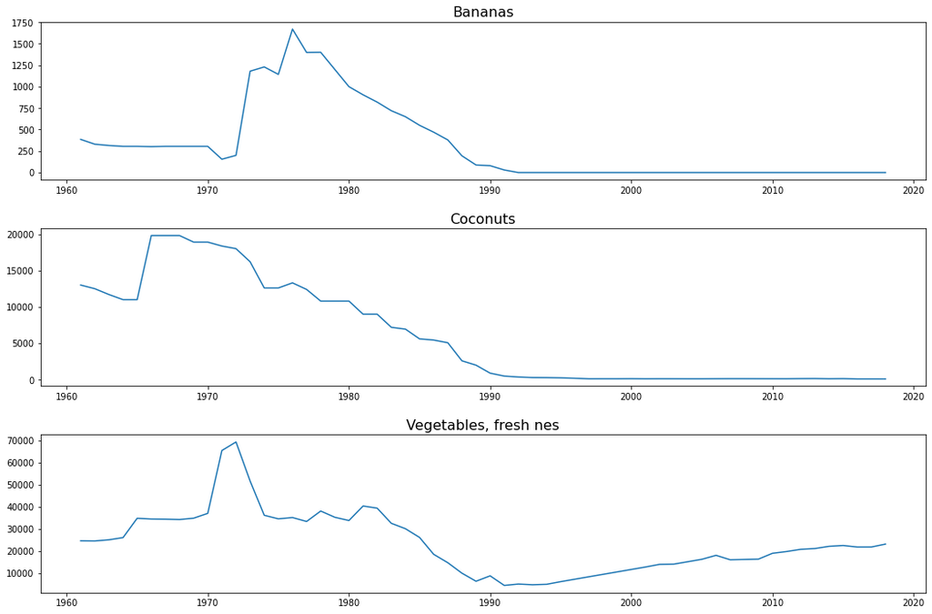

```python
print("Crop Production")
small_plot(all_crops_production, ["Bananas", "Coconuts", "Vegetables, fresh nes"])
```

It actually looks like despite the overall decrease in coconut production, coconut yield has remained somewhat consistent, if not slightly increasing. So, even though they suck at making a large quantity of coconuts, they do make a good amount of coconuts for the amount of farmland they have.

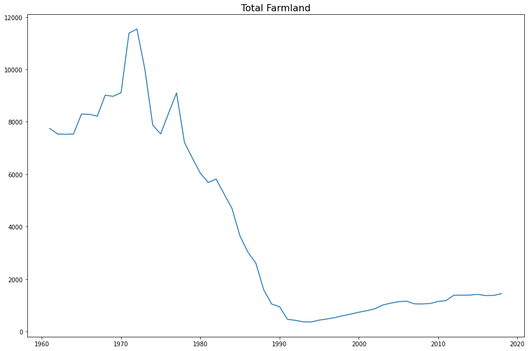

```python
all_crops_area["sum"] = all_crops_area.sum(axis=1) # sum the rows

pyplot.plot(all_crops_area["sum"])
pyplot.title("Total Farmland")
pyplot.show()
```

It looks like the total farmland shot down starting in the 70s and has slowly picked back up since the late 90s. I wonder if this is because they want to rely less on exports for their food. Let's look at industry statistics from the 90s on to validate our hypothesis that industry is replacing agriculture, including our beloved coconut.

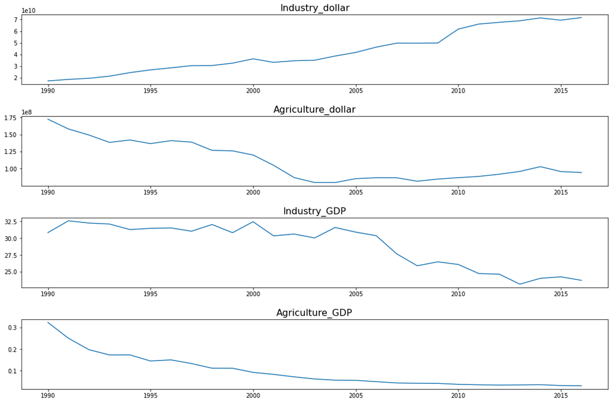

```python
small_plot(industry_stats, industry_stats.columns.values.tolist()[0:4])
```

It looks like industry did replace agriculture, you can see it trending up while agriculture trends down in terms of dollar value. However, industry as a percentage of GDP also starts going down in the 2000s. This might be due to an increased focus on tourism as a main economic force.

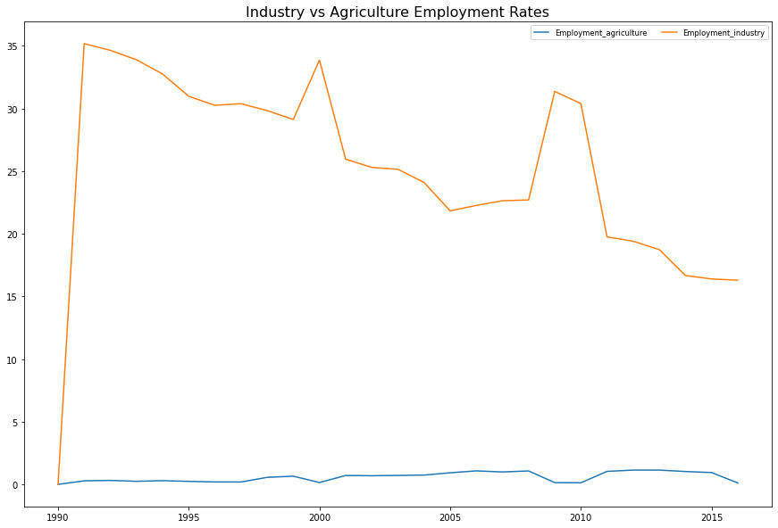

```python
big_plot(industry_stats[["Employment_agriculture", "Employment_industry"]], "Industry vs Agriculture Employment Rates")
```

Industry has clearly been a leader in employment, at least since the 1990s.

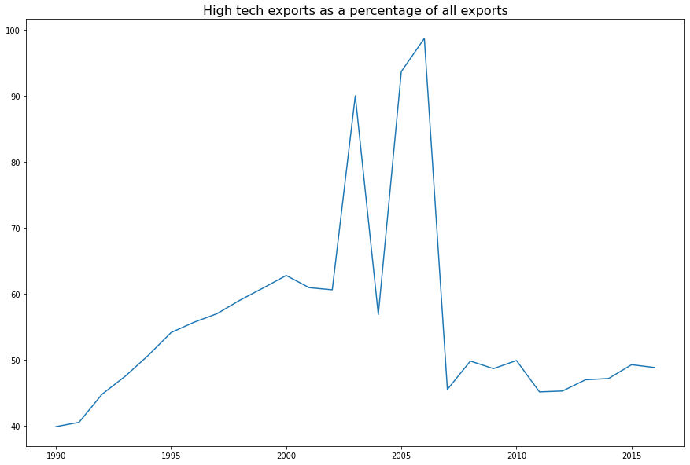

```python
pyplot.plot(industry_stats["High_tech_exports"])
pyplot.title("High tech exports as a percentage of all exports")
pyplot.show()
```

# Conclusions: